# Developing Data Products Course Notes

Xing Su

## Shiny ([tutorial](http://rstudio.github.io/shiny/tutorial/))

- Shiny = platform for creating interactive R program embedded on web pages (made by RStudio)
- knowledge of these helpful: HTML (web page structure), css (style), JavaScript (interactivity)
- **OpenCPU** = project created by Jerom Ooms providing API for creating more complex R/web apps
- `install.packages("shiny"); library(shiny)` = install/load shiny package
- capabilities
  - upload or download files
  - tabbed main panels
  - editable data tables
  - dynamic UI
  - user defined inputs/outputs
  - submit button to control when calculations/tasks are processed

### Structure of Shiny App

- **two** scripts (in one directory) make up a Shiny project
  - `ui.R` - controls appearance/all style elements
    - alternatively, a `www` directory with an `index.html` file enclosed can be used instead of `ui.R`
      - **Note**: output is rendered into HTML elements based on matching their id attribute to an output slot and by specifying the requisite css class for the element (in this case either `shiny-text-output`, `shiny-plot-output`, or `shiny-html-output`)
      - it is possible to create highly customized user-interfaces using user-defined HTML/CSS/JavaScript
  - `server.R` - controls functions
- `runApp()` executes the Shiny application
  - `runApp(display.mode = 'showcase')` = displays the code from `ui.R` and `server.R` and highlights what is being executed depending on the inputs
- **Note**: `","` must be included **ONLY INBETWEEN** objects/functions on the same level

### ui.R

- `library(shiny)` = first line, loads the shiny package
- `shinyUI()` = shiny UI wrapper, contains sub-methods to create panels/parts/viewable object
- `pageWithSideBar()` = creates page with main/side bar division
- `headerPanel("title")` = specifies header of the page
- `sideBarPanel()` = specifies parameters/objects in the side bar (on the **left**)
- `mainPanel()` = specifies parameters/objects in the main panel (on the **right**)
- for better control over style, use `shinyUI(fluidpage())` ([tutorial](http://shiny.rstudio.com/articles/layout-guide.html)) <– produces responsive web pages
  - `fluidRow()` = creates row of content with width 12 that can be subdivided into columns
    - `column(4, ...)` = creates a column of width 4 within the fluid row
    - `style = "CSS"` = can be used as the last element of the column to specify additional style
- `absolutePanel(top=0, left=0, right=0)` = used to produce floating panels on top of the page ([documentation](http://shiny.rstudio.com/reference/shiny/latest/absolutePanel.html))
  - `fixed = TRUE` = panel will not scroll with page, which means the panel will always stay in the same position as you scroll through the page
  - `draggable = TRUE` = make panel movable by the user
  - `top = 40` / `bottom = 50` = position from the top/bottom edge of the browser window
    - `top = 0, bottom = 0` = creates panel that spans the entire vertical length of window
  - `left = 40` / `right = 50` = position from the left/right edge of the browser window
    - `top = 0, bottom = 0` = creates panel that spans the entire horizontal length of window
  - `height = 30` / `width = 40` = specifies the height/width of the panel
  - `style = "opacity:0.92; z-index = 100"` = makes panel transparent and ensures the panel is always the top-most element
- **content objects/functions**
  - **Note**: more HTML tags can be found [here](http://shiny.rstudio.com/articles/tag-glossary.html)
  - **Note**: most of the content objects (h1, p, code, etc) can use **both** double and single quotes to specify values, just be careful to be consistent
  - `h1/2/3/4('heading')` = creates heading for the panel
  - `p('pargraph')` = creates regular text/paragraph
  - `code('code')` = renders code format on the page
  - `br()` = inserts line break
  - `tags$hr()` = inserts horizontal line
  - `tags$ol()`/ `tags$ul()` = initiates ordered/unordered list
  - `div( ... , style = "CSS Code")` / `span( ... , style = "CSS Code")` = used to add additional style to particular parts of the app
    - `div` should be used for a section/block, `span` should be used for a specific part/inline
  - `withMathJax()` = add this element to allow Shiny to process LaTeX
    - inline LaTex must be wrapped like this: `\\(LaTeX\\)`
    - block equations are still wrapped by: `$$LaTeX$$`
- **inputs**
  - `textInput(inputId = "id", label = "textLabel")` = creates a plain text input field
    - `inputId` = field identifier
    - `label` = text that appear above/before a field
  - `numericInput('HTMLlabel', 'printedLabel', value = 0, min = 0, max = 10, step = 1)` = create a number input field with incrementer (up/down arrows)
    - `'HTMLLabel'` = name given to the field, not printed, and can be called
    - `'printedLabel'` = text that shows up above the input box explaining the field
    - `value` = default numeric value that the field should take; 0 is an example
    - `min` = minimum value that can be set in the field (if a smaller value is manually entered, then the value becomes the minimum specified once user clicks away from the field)
    - `max` = max value that can be set in the field
    - `step` = increments for the up/down arrows
    - more arguments can be found in `?numericInput`
  - `checkboxGroupInput("id2", "Checkbox",choices = c("Value 1" = "1", ...), selected = "1", inline = TRUE)` = creates a series of checkboxes
    - `"id2", "Checkbox"` = field identifier/label
    - `choices` = list of checkboxes and their labels
      - format = `"checkboxName" = "fieldIdentifier"`
      - **Note**: `fieldIdentifier` should generally be different from checkbox to checkbox, so we can properly identify the responses
    - `selected` = specifies the checkboxes that should be selected by default; uses `fieldIndentifier` values
    - `inline` = whether the options should be displayed inline
  - `dateInput("fieldID", "fieldLabel")` = creates a selectable date field (dropdown calendar/date picker automatically generated)
    - `"fieldID"` = field identifier
    - `"fieldLabel"` = text/name displayed above fields
    - more arguments can be found in `?dateInput`
  - `submitButton("Submit")` = creates a submit button that updates the output/calculations only when the user submits the new inputs (default behavior = all changes update reactively/in real time)
  - `actionButton(inputId = "goButton", label = "test")` = creates a button with the specified label and id
    - output can be specified for when the button is clicked
  - `sliderInput("id", "label", value = 70, min = 62, max = 74, 0.05)` = creates a slider for input
    - arguments similar to `numericInput` and more information can be found `?sliderInput`
- **outputs**
  - **Note**: every variable called here must have a corresponding method corresponding method from the `output` element in `server.R` to render their value
  - `textOutput("fieldId", inline = FALSE)` = prints the value of the variable/field in text format
    - `inline = TRUE` = inserts the result inline with the HTML element
    - `inline = FALSE` = inserts the result in block code format
  - `verbatimTextOutput("fieldId")` = prints out the value of the specified field defined in `server.R`
  - `plotOutput('fieldId')` = plots the output (‘sampleHist’ for example) created from `server.R` script
  - `output$test <- renderText({input$goButton}); isolate(paste(input$t1, input$2))})` = `isolate` action executes when the button is pressed
    - `if (input$goButton == 1){ Conditional statements }` = create different behavior depending on the number of times the button is pressed

### ui.R Example

- below is part of the ui.R code for a project on Shiny

```r
# load shiny package
library(shiny)
# begin shiny UI
shinyUI(navbarPage("Shiny Project",
    # create first tab
    tabPanel("Documentation",
        # load MathJax library so LaTeX can be used for math equations
        withMathJax(), h3("Why is the Variance Estimator \\(S^2\\) divided by \\(n-1?\\)"),
        # paragraph and bold text
        p("The ", strong("sample variance")," can be calculated in ", strong(em("two")),
          " different ways:",
          "$$S^2 \\mbox{(unbiased)} = \\frac{\\sum_{i=1}^n (X_i - \\bar X)^2}{n-1}
          ~~~\\mbox{and}~~S^2\\mbox{(biased)}=\\frac{\\sum_{i=1}^n (X_i-\\bar X)^2}{n}$$",
          "The unbiased calculation is most often used, as it provides a ",
          strong(em("more accurate")), " estimate of population variance"),
        # break used to space sections
        br(), p("To show this empirically, we simulated the following in the ",
                strong("Simulation Experiment"), " tab: "), br(),
        # ordered list
        tags$ol(
            tags$li("Create population by drawing observations from values 1 to 20."),
            tags$li("Draw a number of samples of specified size from the population"),
            tags$li("Plot difference between sample and true population variance"),
            tags$li("Show the effects of sample size vs accuracy of variance estimated")
        )),
    # second tab
    tabPanel("Simulation Experiment",
        # fluid row for space holders
        fluidRow(
            # fluid columns
            column(4, div(style = "height: 150px")),
            column(4, div(style = "height: 150px")),
            column(4, div(style = "height: 150px"))),
        # main content
        fluidRow(
            column(12,h4("We start by generating a population of ",
                         span(textOutput("population", inline = TRUE),
                         style = "color: red; font-size: 20px"),
                         " observations from values 1 to 20:"),
                   tags$hr(),htmlOutput("popHist"),
                   # additional style
                   style = "padding-left: 20px"
            )
        ),
        # absolute panel
        absolutePanel(
            # position attributes
            top = 50, left = 0, right =0,
            fixed = TRUE,
            # panel with predefined background
            wellPanel(
                fluidRow(
                    # sliders
                    column(4, sliderInput("population", "Size of Population:",
                                          min = 100, max = 500, value = 250),
                           p(strong("Population Variance: "),
                           textOutput("popVar", inline = TRUE))),
                    column(4, sliderInput("numSample", "Number of Samples:",
                                          min = 100, max = 500, value = 300),
                           p(strong("Sample Variance (biased): "),
                           textOutput("biaVar", inline = TRUE))),
                    column(4, sliderInput("sampleSize", "Size of Samples:",
                                          min = 2, max = 15, value = 10),
                           p(strong("Sample Variance (unbiased): "),
                           textOutput("unbiaVar", inline = TRUE)))),
                style = "opacity: 0.92; z-index: 100;"
            ))
    )
))
```

### server.R

- preamble/code to set up environment (executed only *once*)
  - start with `library()` calls to load packages/data
  - define/initiate variables and relevant default values
    - `<<-` operator should be used to assign values to variables in the parent environment
    - `x <<- x + 1` will define x to be the sum of 1 and the value of x (defined in the parent environment/working environment)
  - any other code that you would like to only run once
- `shinyServer()` = initiates the server function
  - `function(input, output){}` = defines a function that performs actions on the inputs user makes and produces an output object
  - **non-reactive** statements/code will be executed *once for each page refresh/submit*
  - **reactive** functions/code are *run repeatedly* as values are updated (i.e. render)
    - **Note**: Shiny only runs what is needed for reactive statements, in other words, the rest of the code is left alone
    - `reactive(function)` = can be used to wrap functions/expressions to create reactive expressions
      - `renderText({x()})` = returns value of x, “()” must be included (syntax)
- **reactive function example**

  ```r
  # start shinyServer
  shinyServer(
  # specify input/output function
  function(input, output) {
      # set x as a reactive function that adds 100 to input1
      x <- reactive({as.numeric(input$text1)+100})
      # set value of x to output object text1
      output$text1 <- renderText({x()                          })
      # set value of x plus value of input object text2 to output object text1
      output$text2 <- renderText({x() + as.numeric(input$text2)})
  }
  )
  ```

- **functions/output objects in `shinyServer()`**
  - `output$oid1 <- renderPrint({input$id1})` = stores the user input value in field `id1` and stores the rendered, printed text in the `oid1` variable of the `output` object
    - `renderPrint({expression})` = reactive function to render the specified expression
    - `{}` is used to ensure the value is an expression
    - `oid1` = variable in the output object that stores the result from the subsequent command
  - `output$sampleHist <- renderPlot({code})` = stores plot generated by code into `sampleHist` variable
    - `renderPlot({code})` = renders a plot generated by the enclosed R code
  - `output$sampleGVisPlot <- renderGvis({code})` = renders Google Visualization object

### server.R Example

- below is part of the server.R code for a project on Shiny that uses googleVis

```r
# load libraries
library(shiny)
require(googleVis)
# begin shiny server
shinyServer(function(input, output) {
    # define reactive parameters
    pop<- reactive({sample(1:20, input$population, replace = TRUE)})
    bootstrapSample<-reactive({sample(pop(),input$sampleSize*input$numSample,
        replace = TRUE)})
    popVar<- reactive({round(var(pop()),2)})
    # print text through reactive funtion
    output$biaVar <- renderText({
        sample<- as.data.frame(matrix(bootstrapSample(), nrow = input$numSample,
            ncol =input$sampleSize))
        return(round(mean(rowSums((sample-rowMeans(sample))^2)/input$sampleSize), 2))
    })
    # google visualization histogram
    output$popHist <- renderGvis({
        popHist <- gvisHistogram(data.frame(pop()), options = list(
            height = "300px",
            legend = "{position: 'none'}", title = "Population Distribution",
            subtitle = "samples randomly drawn (with replacement) from values 1 to 20",
            histogram = "{ hideBucketItems: true, bucketSize: 2 }",
            hAxis = "{ title: 'Values', maxAlternation: 1, showTextEvery: 1}",
            vAxis = "{ title: 'Frequency'}"
        ))
        return(popHist)
    })
})
```

### Distributing Shiny Application

- running code locally = running local server and browser routing through local host
- quickest way = send application directory
- possible to create R package and create a wrapper that calls `runApp` (requires R knowledge)
- another option = run shiny server ([link](http://www.rstudio.com/shiny/server/))

### Debugging

- `runApp(display.mode = 'showcase')` = highlights execution while running a shiny application
- `cat` = can be used to display output to stdout/R console
- `browser()` = interrupts execution ([tutorial](http://shiny.rstudio.com/articles/debugging.html))

## `manipulate` Package

- `manipulate` = package/function can be leveraged to create quick interactive graphics by allowing the user to vary the different variables to a model/calculation
- creates sliders/checkbox/picker for the user ([documentation](http://www.rstudio.com/ide/docs/advanced/manipulate))

### Example

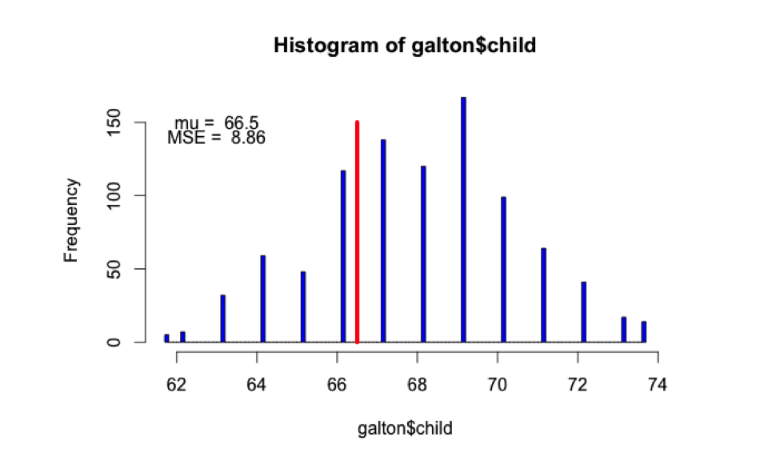

```r
# load data and manipulate package
library(UsingR)
library(manipulate)
# plotting function
myHist <- function(mu){
    # histogram
    hist(galton$child,col="blue",breaks=100)
    # vertical line to highlight the mean
    lines(c(mu, mu), c(0, 150),col="red",lwd=5)
    # calculate mean squared error
    mse <- mean((galton$child - mu)^2)
    # updates the mean value as the mean is changed by the user
    text(63, 150, paste("mu = ", mu))
    # updates the mean squared error value as the mean is changed by the user
    text(63, 140, paste("MSE = ", round(mse, 2)))
}
# creates a slider to vary the mean for the histogram
manipulate(myHist(mu), mu = slider(62, 74, step = 0.5))
```

## rCharts

- rCharts = simple way of creating interactive JavaScript visualization using R
  - more in-depth knowledge of D3 will be needed to create more complex tools
  - written by Ramnath Vaidyanathan
  - uses formula interface to specify plots (like the `lattice` plotting system)
  - displays interactive tool tips when hovering over data points on the plots
- **installation**
  - `devtools` must be installed first (`install.packages("devtools")`)
  - `require(devtools); install_github('rCharts', 'ramnathv')` installs the rCharts package from GitHub
- **plot types**
  - **Note**: each of the following JS library has different default styles as well as a multitude of capabilities; the following list is just what was demonstrated and more documentation can be found in the corresponding links
  - [*Polychart* [js library](https://github.com/Polychart/polychart2)] `rPlot` –> paneled scatter plots
  - [*Morris* [js library](https://github.com/oesmith/morris.js)] `mPlot` –> time series plot (similar to stock price charts)
  - [*NVD3* [js library](http://nvd3.org/)] `nPlot` –> stacked/grouped bar charts
  - [*xCharts* [js library](https://github.com/tenXer/xcharts/)] –> shaded line graphs
  - [*HighChart* [js library](http://www.highcharts.com/)] –> stacked (different styles) scatter/line charts
  - [*LeafLet* [js library](http://leafletjs.com/)] –> interactive maps
  - [*Rickshaw* [js library](http://ramnathv.github.io/rCharts/)] –> stacked area plots/time series
- rChart objects have various attributes/functions that you can use when saved `n1 <- nplot(...)`
  - `n1$` + TAB in R Console brings up list of all functions contained in the object
  - `n1$html()` = prints out the HTML for the plot
  - `n1$save(filename)` = embeds code into slidify document
  - `n1$print()` = print out the JavaScript
  - `n1$show("inline", include_assets = TRUE, cdn = F)` = embed HTML/JS code directly with in Rmd file (for HTML output)
  - `n1$publish('plotname', host = 'gist'/'rpubs')` = publishes the plot under the specified `plotname` as a `gist` or to `rpubs`
- to use with *slidify*, the following YAML (Yet Another Markup Language/YAML Ain’t Markup Language) must be added
  - `yaml ext_widgets : {rCharts: ["libraries/nvd3"]}`

### Example

```r
# load rCharts package
require(rCharts); library(datasets); library(knitr)
# create dataframe with HairEyeColor data
haireye = as.data.frame(HairEyeColor)
# create a nPlot object
n1 <- nPlot(Freq ~ Hair, group = 'Eye', type = 'multiBarChart',
            data = subset(haireye, Sex == 'Male'))
# save the nPlot object to a html page
n1$show("inline", include_assets = TRUE, cdn = F)
```

## GoogleVis API

- GoogleVis allows R to create interactive HTML graphics (Google Charts)
- **chart types** (format = gvis+ChartType)
  - Motion charts: `gvisMotionChart`
  - Interactive maps: `gvisGeoChart`
  - Interactive tables: `gvisTable`
  - Line charts: `gvisLineChart`
  - Bar charts: `gvisColumnChart`
  - Tree maps: `gvisTreeMap`
  - more charts can be found [here](http://cran.r-project.org/web/packages/googleVis/googleVis.pdf)
- configuration options and default values for arguments for each of the plot types can be found [here](https://developers.google.com/chart/interactive/docs/gallery/geochart)
- `print(chart, "chart")` = prints the JavaScript for creating the interactive plot so it can be embedded in slidify/HTML document
  - `print(chart)` = prints HTML + JavaScript directly
- alternatively, to print the charts on a HTML page, you can use `op <- options(gvis.plot.tag='chart')`
  - this sets the googleVis options first to change the behaviour of `plot.gvis`, so that *only the chart component* of the HTML file is written into the output file
  - `plot(chart)` can then be called to print the plots to HTML
- `gvisMerge(chart1, chart2, horizontal = TRUE, tableOptions = "bgcolor = \"#CCCCCC\" cellspacing = 10)` = combines the two plots into one horizontally (1 x 2 panel)
  - **Note**: `gvisMerge()` can only combine **TWO** plots at a time
  - `horizontal = FALSE` = combines plots vertically (TRUE for horizontal combination)
  - `tableOptions = ...` = used to specify attributes of the combined plot
- `demo(googleVis)` = demos how each of the plot works
- **resources**
  - [vignette](http://cran.r-project.org/web/packages/googleVis/vignettes/googleVis.pdf)
  - [documentation](http://cran.r-project.org/web/packages/googleVis/googleVis.pdf)
  - [plot gallery](https://developers.google.com/chart/interactive/docs/gallery)
  - [FAQ](https://developers.google.com/chart/interactive/faq)

### Example (line chart)

```r
# load googleVis package
library(googleVis)
# set gvis.plot options to only return the chart
op <- options(gvis.plot.tag='chart')
# create initial data with x variable as "label" and y variable as "var1/var2"
df <- data.frame(label=c("US", "GB", "BR"), val1=c(1,3,4), val2=c(23,12,32))
# set up a gvisLineChart with x and y
Line <- gvisLineChart(df, xvar="label", yvar=c("val1","val2"),
        # set options for the graph (list) - title and location of legend
        options=list(title="Hello World", legend="bottom",
                # set title text style
                titleTextStyle="{color:'red', fontSize:18}",
                # set vertical gridlines
                vAxis="{gridlines:{color:'red', count:3}}",
                # set horizontal axis title and style
                hAxis="{title:'My Label', titleTextStyle:{color:'blue'}}",
                # set plotting style of the data
                series="[{color:'green', targetAxisIndex: 0},
                         {color: 'blue',targetAxisIndex:1}]",
                # set vertical axis labels and formats
                vAxes="[{title:'Value 1 (%)', format:'##,######%'},
                                  {title:'Value 2 (\U00A3)'}]",
                # set line plot to be smoothed and set width and height of the plot
                curveType="function", width=500, height=300
                ))
# print the chart in JavaScript
plot(Line)
```

### Example (merging graphs)

```r
G <- gvisGeoChart(Exports, "Country", "Profit",options=list(width=200, height=100))
T1 <- gvisTable(Exports,options=list(width=200, height=270))
M <- gvisMotionChart(Fruits, "Fruit", "Year", options=list(width=400, height=370))
GT <- gvisMerge(G,T1, horizontal=FALSE)
GTM <- gvisMerge(GT, M, horizontal=TRUE,tableOptions="bgcolor=\"#CCCCCC\" cellspacing=10")
plot(GTM)
```

- **Note**: the motion chart only displays when it is hosted on a server or a trusted Macromedia source, see [googlVis vignette](http://cran.r-project.org/web/packages/googleVis/vignettes/googleVis.pdf) for more details

## ShinyApps.io (https://www.shinyapps.io)

- platform created by RStudio to share Shiny apps on the web
- log in through GitHub/Google, and set up access in R
  1. Make sure you have `devtools` installed in R (`install.packages("devtools")`)
  2. enter `devtools::install_github('rstudio/shinyapps')`, which installs the `shinyapps` package from GitHub
  3. follow the instructions to authenticate your shiny apps account in R through the generated token
  4. publish your app through `deployApp()` command
- the apps your deploy will be hosted on ShinyApps.io under your account

## plot.ly (https://plot.ly/)

- platform share and edit plots modularly on the web ([examples](https://plot.ly/feed/))
  - every part of the plot can be customized and modified
  - graphs can be converted from one language to another
- you can choose to log in through Facebook/Twitter/Google/GitHub
  1. make sure you have `devtools` installed in R
  2. enter `devtools::install_github("ropensci/plotly")`, which installs `plotly` package from GitHub
  3. go to https://plot.ly/r/getting-started/ and follow the instructions
  4. enter `library(plotly); set_credentials_file("<username>", "<token>")` with the appropriate username and token filled in
  5. use `plotly()` methods to upload plots to your account
  6. modify any part of the plot as you like once uploaded
  7. share the plot

### Example

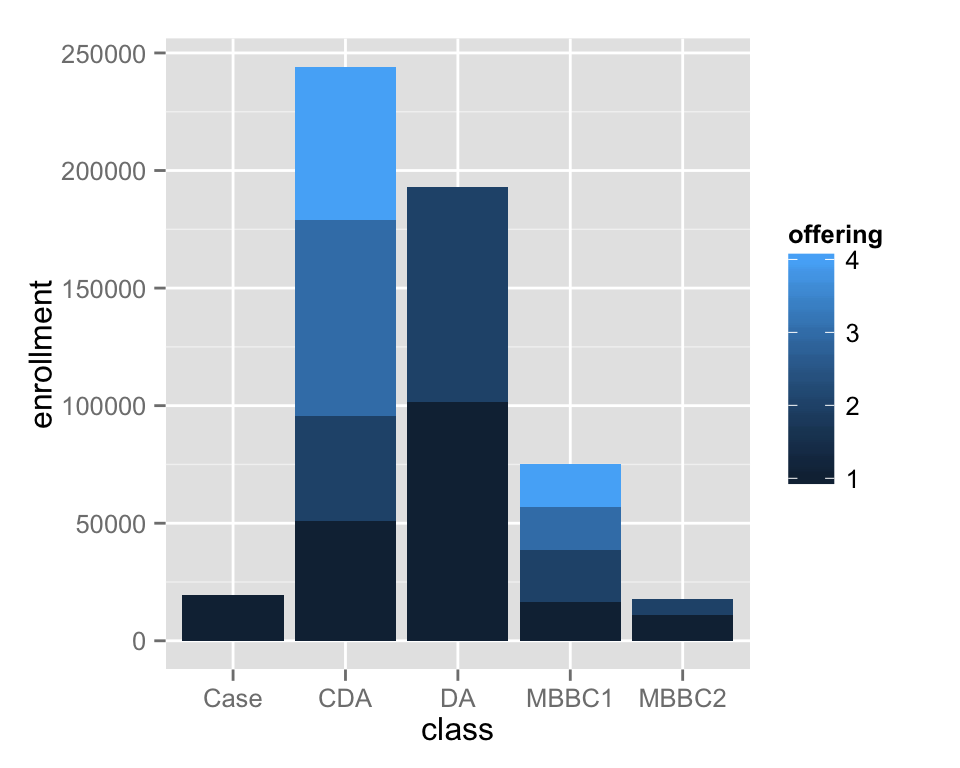

```r
# load packages
library(plotly); library(ggplot2)
# make sure your plot.ly credentials are set correctly using the following command
#   set_credentials_file(username=FILL IN, api_key=FILL IN)
# load data
load("courseraData.rda")
# bar plot using ggplot2
g <- ggplot(myData, aes(y = enrollment, x = class, fill = offering))
g <- g + geom_bar(stat = "identity")
g
```

```r
# initiate plotly object
py <- plotly()
# interface with plot.ly and ggplot2 to upload the plot to plot.ly under your credentials
out <- py$ggplotly(g)
# typing this in R console will return the url of the generated plot
out$response$url
```

```
## [1] "https://plot.ly/~sxing/44"
```

- the above is the response URL for the plot created on plot.ly
- **Note**: this particular URL corresponds to the plot on my personal account

## Structure of a Data Analysis Report

- can be blog post or formal report for analysis of given dataset
- components
  - **prompt** file = analysis being performed (this file is not mandatory/available in all cases)
  - **data** folder = data to be analyzed + report files
    - **Note**: always keep track of data provenance (for reproducibility)
  - **code** folder= rawcode vs finalcode
    - *rawcode* = analysis performed (`.Rmd` file)
      - all exploratory data analysis
      - not for sharing with others
    - *finalcode* = only analysis to be shared with other people/summarizations (`.Rmd` file)
      - not necessarily final but pertinent to analysis discussed in final report
    - **figures** folder = final plots that have all appropriate formatting for distribution/presentation
    - **writing** folder = final analysis report and final figure caption
      - report should have the following sections: title, introduction, methods, results, conclusions, references
      - final figure captions should correspond with the figures created

## Slidify

- create data-centric presentations created by Ramnath Vaidyanathan
- amalgamation of knitr, Markdown, JavaScript libraries for HTML5 presentations
- easily extendable/customizable
- allows embedded code chunks and mathematical formulas (MathJax JS library) to be rendered correctly
- final products are HTML files, which can be viewed with any web browser and shared easily
- **installation**
  1. make sure you have `devtools` package installed in R
  2. enter `install_github('slidify', 'ramnathv'); install_github('slidifyLibraries', 'ramnathv')` to install the slidify packages
  3. load slidify package with `library(slidify)`
  4. set the working directory to the project you are working on with `setwd("~/project")`
- `author("title")` = sets up initial files for a new slidify project (performs the following things)
  1. `title` (or any name you typed) directory is created inside the current working directory
  2. `assets` subdirectory and a file named `index.Rmd` are created inside `title` directory
  3. `assets` subdirectory is populated with the following empty folders:
     - `css`
     - `img`
     - `js`
     - `layouts`
     - **Note**: any custom CSS/images/JavaScript you want to use should be put into the above folders correspondingly
  4. `index.Rmd` R Markdown file will open up in RStudio
- `slidify("index.Rmd")` = processes the R Markdown file into a HTML page and imports all necessary libraries
- `library(knitr); browseURL("index.html")` = opens up the built-in web browser in R Studio and displays the slidify presentation
  - **Note**: this is only necessary the first time; you can refresh the page to reflect any changes after saving the HTML file

### YAML (YAML Ain’t Markup Language/Yet Another Markup Language)

- used to specify options for the R Markdown/slidify at the beginning of the file
- format: `field : value # comment`
  - `title` = title of document
  - `subtitle` = subtitle of document
  - `author` = author of document
  - `job` = occupation of author (can be left blank)
  - `framework` = controls formatting, usually the name of a library is used (i.e. `io2012`)
    - [io2012](https://code.google.com/p/io-2012-slides/)
    - [html5slides](https://code.google.com/p/html5slides/)
    - [deck.js](http://imakewebthings.com/deck.js/)
    - [dzslides](http://paulrouget.com/dzslides/)
    - landslide
    - [Slidy](http://www.w3.org/Talks/Tools/Slidy2/Overview.html#)
  - `highlighter` = controls effects for presentation (i.e `highlight.js`)
  - `hitheme` = specifies theme of code (i.e. `tomorrow`)
  - `widgets` = loads additional libraries to display LaTeX math equations(`mathjax`), quiz-styles components (quiz), and additional style (`bootstrap` –> Twitter-created style)
    - for math expressions, the code should be enclosed in `$expresion$` for inline expressions, and `$$expression$$` for block equations
  - `mode = selfcontained/standalone/draft` –> depending whether the presentation will be given with Internet access or not
    - `standalone` = all the JavaScript libraries will be save locally so that the presentation can be executed without Internet access
    - `selfcontained` = load all JavaScript library at time of presentation
  - `logo` = displays a logo in title slide
  - `url` = specify path to assets/other folders that are used in the presentation
    - **Note**: `../` signifies the parent directory
- **example**

```yaml
---
title       : Slidify
subtitle    : Data meets presentation
author      : Jeffrey Leek, Assistant Professor of Biostatistics
job         : Johns Hopkins Bloomberg School of Public Health
logo        : bloomberg_shield.png
framework   : io2012        # {io2012, html5slides, shower, dzslides, ...}
highlighter : highlight.js  # {highlight.js, prettify, highlight}
hitheme     : tomorrow      #
url:
  lib: ../../libraries
  assets: ../../assets
widgets     : [mathjax]            # {mathjax, quiz, bootstrap}
mode        : selfcontained # {standalone, draft}
---
```

### Slides

- `##` = signifies the title of the slide –> equivalent of `h1` element in HTML
- `---` = marks the end of a slide
- `.class #id` = assigns `class` and `id` attributes (CSS) to the slide and can be used to customize the style of the page
- **Note**: make sure to leave space between each component of the slidify document (title, code, text, etc) to avoid errors
- advanced HTML can be added directly to the `index.Rmd` file and most of the time it should function correctly
- interactive element (quiz questions, rCharts, shiny apps) can be embedded into slidify documents ([demos](http://slidify.github.io/dcmeetup/demos/interactive/))
  - quiz elements
    - `##` = signifies title of questions
    - the question can be type in plain text format
    - the multiple choice options are listed by number (`1. a`, `2. b`, etc.)
      - wrap the correct answer in underscores (`2. _b_`)
    - `*** .hint` = denotes the hint that will be displayed when the user clicks on *Show Hint* button
    - `*** .explanation` = denotes the explanation that will be displayed when the user clicks on *Show Answer* button
    - a page like the one below will be generated when processed with slidify

```
## Question 1

What is 1 + 1?

1. 1
2. _2_
3. 3
4. 4

*** .hint
This is a hint

*** .explanation
This is an explanation
```

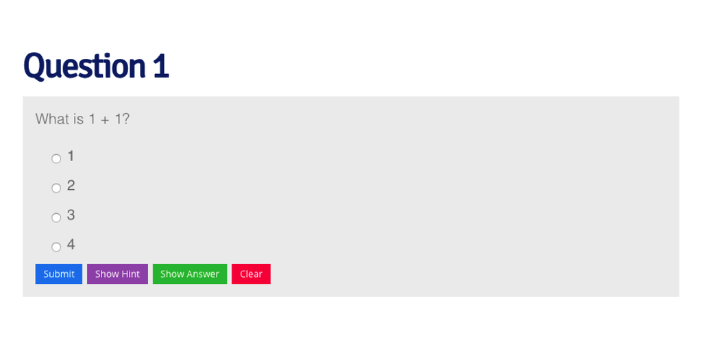

* **`knit HTML`** button can be used to generate previews for the presentation as well

### Publishing

- first, you will need to create a new repository on GitHub
- `publish_github("user", "repo")` can be used to publish the slidify document on to your on-line repo

## RStudio Presentation

- presentation authoring tool within the RStudio IDE ([tutorial](http://www.rstudio.com/ide/docs/presentations/overview))
- output = html5 presentation
- `.Rpres` file –> converted to `.md` file –> `.html` file
- uses R Markdown format as slidify/knitr
  - **mathjax** JS library is loaded by default
- RStudio format/runs the code when the document is saved

### Creating Presentation

- file –> New File –> R Presentation (`alt` + `f` + `p`)
- `class: classname` = specify slide-specific control from CSS
- `css: file.css` = can be used to import an external CSS file
  - alternatively, a css file that has the same name as the presentation will be automatically loaded
- knowledge of CSS/HTML/JavaScript useful to customize presentation more granularly
  - **Note**: though the end HTML file can be edited directly, it should be used as a last resort as it defeats the purpose of reproducible presentations
- clicking on **Preview** button brings up *Presentation* viewer in RStudio
  - *navigation controls* (left and right arrows) are located in right bottom corner
  - the *Notepad* icon on the menu bar above displays the section of code that corresponds with the current slide in the main window
  - the *More* button has four options
    - “Clear Knitr Cache” = clears cache for the generated presentation previews
    - “View in Browser” = creates temporary HTML file and opens in default web browser (does not create a local file)
    - “Save as Web Page” = creates a copy of the presentation as a web page
    - “Publish to RPubs” = publishes presentation on RPubs
  - the *Refresh* button refreshes the page
  - the *Zoom* button opens a new window to display the presentation
- **transitions between slides**
  - just after the beginning of each slide, the `transition` property (similar to YAML) can be specified to control the transition between the previous and current slides
  - `transition: linear` = creates 2D linear transition (html5) between slides
  - `transition: rotate` = creates 3D rotating transition (html5) between slides
  - more transition options are found [here](https://support.rstudio.com/hc/en-us/articles/200714013-Slide-Transitions-and-Navigation)
- **hierarchical organization**
  - attribute `type` can be added to specify the appearance of the slide (“slide type”)
  - `type: section` and `type: sub-section` = distinct background and font colors, slightly larger heading text, appear at a different indent level within the slide navigation menu
  - `type: prompt` and `type: alert` = distinct background color to communicate to viewers that the slide has different intent
- **columns**
  - simply place `***` in between two sections of content on a slide to separate it into two columns
  - `left: 70%` can be used to specify the proportions of each column
  - `right: 30%` works similarly
- **change slide font ([guide](https://support.rstudio.com/hc/en-us/articles/200532307-Customizing-Fonts-and-Appearance))**
  - `font-family: fontname` = changes the font of slide (specified in the same way as HTML)
  - `font-import: http://fonts.googleapis.com/css?family=Risque` = imports font
    - **Note**: fonts must be present on the system for presentation (or have Internet), or default fonts will be used
  - **Note**: CSS selectors for class and IDs must be preceded by `.reveal` to work (`.reveal section del` applies to any text enclosed by `~~text~~`)

## Slidify vs RStudio Presenter

- **Slidify**
  - flexible control from the `.Rmd` file
  - under constant development
  - large user base, more likely to get answer on *StackOverflow*
  - lots of styles and options by default
  - steeper learning curve
  - more command-line oriented
- **R Studio Presenter**
  - embedded in R Studio
  - more GUI oriented
  - very easy to get started
  - smaller set of easy styles and options
  - default styles look nice
  - as flexible as Slidify with CSS/HTML knowledge

## R Package

- R packages = collection of functions/data objects, extends base functionality of R
  - organized to provide consistency
  - written by people all over the world
- primarily available from CRAN and Bioconductor
  - installed with `install.packages()`
- also available on GitHub/BitBucket/etc
  - installed using `devtools::install_github()`
- **documentation/vignettes** = forces author to provide detailed explanation for the arguments/results of their functions and objects
  - allows for well defined Application Programming Interface (API) to tell users what and how to use the functions
  - much of the implementation details can be hidden from the user so that updates can be made without interfering with use cases
- if package is available on CRAN then it must hold standards of reliability and robustness
- fairly easily maintained with proper documentation
- **package development process**
  - write code in R script
  - desire to make code available to others
  - incorporate R script file into R package structure
  - write documentation for user functions
  - include examples/demos/datasets/tutorials
  - package the contents
  - submit to CRAN/Bioconductor
  - push source code repository to GitHub/other code sharing site
    - people find problems with code and expect the author to fix it
    - alternatively, people might fix the problem and show the author the changes
  - incorporate changes and release a new version

### R Package Components

- *directory* with name of R package = created as first step
- *DESCRIPTION file* = metadata/information about package
- *R code* = code should be in `R/` sub-directory
- *Documentation* = file should be in `man/` sub-directory
- *NAMESPACE* = optional but common and best practice
- full requirements documented in [Writing R Extensions](http://cran.r-project.org/doc/manuals/r-release/R-exts.html)

### DESCRIPTION file

- *Package* = name of package (e.g. `library(name)` to load the package)
- *Title* = full name of package
- *description* = longer description of package in one or two sentences
- *Version* = version number (usually `M.m-p` format, “majorNumber.minorNumber-patchLevel”)
- *Author* = Name of the original author(s)
- *Maintainer* = name + email of person (maintainer) who fixes problems
- *License* = license for the source code, describes the term that the source code is released under
  - common licenses include GNU/BSD/MIT
  - typically a standard open source license is used
- optional fields
  - *Depends* = R packages that your package depends on
  - *Suggests* = optional R packages that users may want to have installed
  - *Date* = release date in YYYY-MM-DD format
  - *URL* = package home page/link to repository
  - *Other* = fields can be added (generally ignored by R)
- *example: `gpclib`*
  - *Package*: gpclib
  - *Title*: General Polygon Clipping Library for R
  - *Description*: General polygon clipping routines for R based on Alan Murta’s C library
  - *Version*: 1.5-5
  - *Author*: Roger D. Peng rpeng@jhsph.edu with contributions from Duncan Murdoch and Barry Rowlingson; GPC library by Alan Murta
  - *Maintainer*: Roger D. Peng rpeng@jhsph.edu
  - *License*: file LICENSE
  - *Depends*: R (>= 2.14.0), methods
  - *Imports*: graphics
  - *Date*: 2013-04-01
  - *URL*: http://www.cs.man.ac.uk/~toby/gpc/, http://github.com/rdpeng/gpclib

### R Code

- copy R code to `R/` directory
- can be any number of files
- separate out files to logical groups (read/fit models)
- all code should be included here and not anywhere else in the package

### NAMESPACE file

- effectively an API for the package
- indicates which functions are *exported* –> public functions that users have access to and can use
  - functions not exported cannot be called directly by the user
  - hides the implementation details from the users (clean package interface)
- lists all dependencies on other packages/indicate what functions you *imported* from other packages
  - allows for your package to use other packages without making them visible to the user
  - importing a function loads the package but *does not* attach it to the search list
- **key directives**
  - `export("\<function>")` = export a function
  - `import("\<package>")` = import a package
  - `importFrom("\<package>", "\<function>")` = import specific function from a package
  - `exportClasses("\<class>")` = indicate the new types of S4 (4<sup>th</sup> version of *S*) classes created with the package (objects of the specified class can be created)
  - `exportMethods("\<generic>")` = methods that can operate on the new class objects
  - **Note**: though they look like R functions, the above directives are not functions that users can use freely
- *example*

```r
# read.polyfile/write.polyfile are functions available to user
export("read.polyfile", "write.polyfile")
# import plot function from graphics package
importFrom(graphics, plot)
# gpc.poly/gpc.poly.nohole classes can be created by the user
exportClasses("gpc.poly", "gpc.poly.nohole")
# the listed methods can be applied to the gpc.poly/gpc.poly.nohole classes
exportMethods("show", "get.bbox", "plot", "intersect”, "union”, "setdiff",
              "[", "append.poly", "scale.poly", "area.poly", "get.pts",
              "coerce", "tristrip", "triangulate")
```

### Documentation

- documentation files (`.Rd`) should be placed in the `man/` sub-directory
- written in specific markup language
- required for every exported function available to the user (serves to limit the number of exported functions)
- concepts/package/datasets overview can also be documented
- **components**
  - `\name{}` = name of function
  - `\alias{}` = anything listed as alias will bring up the help file (`?line` is the same as `?residuals.tukeyline`)
    - multiple aliases possible
  - `\title{}` = full title of the function
  - `\description{}` = full description of the purpose of function
  - `\usage{}` = format/syntax of function
  - `\arguments{}` = explanation of the arguments in the syntax of function
  - `\details{}` = notes/details about limitation/features of the function
  - `\value{}` = specifies what object is returned
  - `\reference{}` = references for the function (paper/book from which the method is created)
- *example: `line` function*

```r
\name{line}
\alias{line}
\alias{residuals.tukeyline}
\title{Robust Line Fitting}
\description{
  Fit a line robustly as recommended in \emph{Exploratory Data Analysis}.
}
\usage{
line(x, y)
}
\arguments{
  \item{x, y}{the arguments can be any way of specifying x-y pairs.  See
    \code{\link{xy.coords}}.}
}
\details{
  Cases with missing values are omitted.

  Long vectors are not supported.
}
\value{
  An object of class \code{"tukeyline"}.

  Methods are available for the generic functions \code{coef},
  \code{residuals}, \code{fitted}, and \code{print}.
}
\references{
  Tukey, J. W. (1977).
  \emph{Exploratory Data Analysis},
  Reading Massachusetts: Addison-Wesley.
}
```